# 99-ACP

### Etapas do processamento

```r
#df.pca <- prcomp(df.scaled, scale = TRUE); df.pca #original
df.pca <- prcomp(df, scale. = TRUE); df.pca
```

```
## Standard deviations (1, .., p=4):
## [1] 1.7083611 0.9560494 0.3830886 0.1439265
##
## Rotation (n x k) = (4 x 4):
##                     PC1         PC2        PC3        PC4
## Sepal.Length  0.5210659 -0.37741762  0.7195664  0.2612863
## Sepal.Width  -0.2693474 -0.92329566 -0.2443818 -0.1235096
## Petal.Length  0.5804131 -0.02449161 -0.1421264 -0.8014492
## Petal.Width   0.5648565 -0.06694199 -0.6342727  0.5235971
```

```r
# Componentes
e.prcomp <- df.pca$rotation; e.prcomp
```

```
##                     PC1         PC2        PC3        PC4
## Sepal.Length  0.5210659 -0.37741762  0.7195664  0.2612863
## Sepal.Width  -0.2693474 -0.92329566 -0.2443818 -0.1235096
## Petal.Length  0.5804131 -0.02449161 -0.1421264 -0.8014492
## Petal.Width   0.5648565 -0.06694199 -0.6342727  0.5235971
```

```r
# Autovalores
lambda.prcomp <- df.pca$sdev; lambda.prcomp
```

```
## [1] 1.7083611 0.9560494 0.3830886 0.1439265
```

```r
# Calculo da variancia explicada por cada componente no PRCOMP
var.prcomp <- df.pca$sdev^2 / sum(df.pca$sdev^2); var.prcomp
```

```
## [1] 0.729624454 0.228507618 0.036689219 0.005178709
```

Dos resultados podemos observar o seguinte:

- O primeiro componente principal explica 73% da variância total no conjunto de dados.
- O segundo componente principal explica 22,8% da variância total no conjunto de dados.
- O terceiro componente principal explica 3,6% da variância total no conjunto de dados.
- O quarto componente principal explica menos de 1% da variância total no conjunto de dados.

### Graficamente

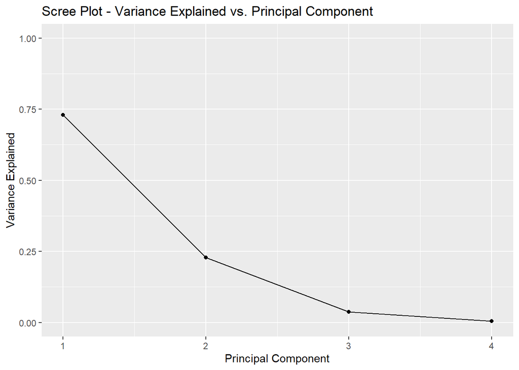

```r
#create scree plot
qplot(c(1:4), var.prcomp) +
  geom_line() +
  xlab("Principal Component") +
  ylab("Variance Explained") +
  ggtitle("Scree Plot - Variance Explained vs. Principal Component") +
  ylim(0, 1)
```

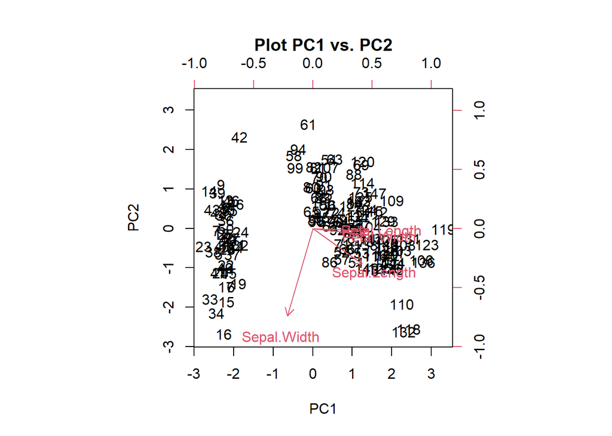

```r
biplot(df.pca, scale = 0, main = 'Plot PC1 vs. PC2')
```

## APC com matriz

Podemos normalizar nosso dataframe. A função [`scale(x)`](http://www.leg.ufpr.br/~walmes/cursoR/guia_rapido_R.pdf) padroniza um vetor/matriz subtraindo os valores de sua média e dividindo pelo desvio padrão. Seria usado o seguindo código.

```r
df.scaled <- scale(df, center = TRUE, scale = TRUE)
```

No lugar disso, vamos usar a matriz de correlação diretamente:

```r
res.cor <- cor(df)
```

```r
# Autovetores e autovetores
res.eig <- eigen(res.cor)
```

Vamos obter os valores os respectivos autovetores normalizados $e_1, e_2, ... , e_p$. Eles possuem os parâmetros da nossa transformação.

```r
# Autovetor
e.manual = res.eig$vectors; e.manual
```

```
##            [,1]        [,2]       [,3]       [,4]
## [1,]  0.5210659 -0.37741762  0.7195664  0.2612863
## [2,] -0.2693474 -0.92329566 -0.2443818 -0.1235096
## [3,]  0.5804131 -0.02449161 -0.1421264 -0.8014492
## [4,]  0.5648565 -0.06694199 -0.6342727  0.5235971
```

Aqui vamos obter os autovalores $\lambda_i$´s.

```r
# Autovalor
lambda.manual = res.eig$values; lambda.manual
```

```
## [1] 2.91849782 0.91403047 0.14675688 0.02071484
```

Vetor com a variância explicada por cada componente.

```r
# Variancia total
var.manual <- res.eig$values/sum(res.eig$values); var.manual
```

```
## [1] 0.729624454 0.228507618 0.036689219 0.005178709
```

Agora vamos obter a matriz de loadings que será confrontada com Análise Fatorial, que será explica logo abaixo:

```r
# Obterndo a matriz de Loadings
k = 2
# Obtendo L
L.hat = t(t(res.eig$vectors[,1:2]) * sqrt(res.eig$values[1:2])); L.hat
```

```
##            [,1]        [,2]
## [1,]  0.8901688 -0.36082989
## [2,] -0.4601427 -0.88271627
## [3,]  0.9915552 -0.02341519
## [4,]  0.9649790 -0.06399985
```

Podemos obter também da seguinte forma:

```r
# Criando a matriz de lambdas
D <- matrix(0, k, k)
diag(D) <- res.eig$values[1:2]

# Criando a matriz de loadings
L.hat2 = as.matrix(res.eig$vectors[,1:2]) %*% sqrt(D); L.hat2
```

```
##            [,1]        [,2]
## [1,]  0.8901688 -0.36082989
## [2,] -0.4601427 -0.88271627
## [3,]  0.9915552 -0.02341519
## [4,]  0.9649790 -0.06399985
```

Comunalidades:

```r
# Criando as comunalidades
h2 <- rowSums(L.hat^2); h2
```

```
## [1] 0.9225986 0.9909193 0.9837300 0.9352804
```

Uniqueness:

```r
# Criando uniques
u2 <- 1 - h2; u2
```

```
## [1] 0.077401362 0.009080678 0.016270047 0.064719625
```

Para obter $Y_j = e_j' X = e_{j1} X_1 + e_{j2} X_2 + ... + e_{j2} X_j$, vamos realizar a multiplicação matricial $e_j' X$. Lembre-se que X, por definição, é uma transposta do data.frame. Assim:

```r
# Transpose eigeinvectors
e.manual_t <- t(e.manual); e.manual_t
```

```
##            [,1]       [,2]        [,3]        [,4]
## [1,]  0.5210659 -0.2693474  0.58041310  0.56485654
## [2,] -0.3774176 -0.9232957 -0.02449161 -0.06694199
## [3,]  0.7195664 -0.2443818 -0.14212637 -0.63427274
## [4,]  0.2612863 -0.1235096 -0.80144925  0.52359713
```

Multiplicamos pelo dataframe original. Considerando que cada componente é $Y_j = e_j' X$, vamos calcular nossas componentes:

```r
# The new dataset: componentes
Y <- e.manual_t %*% t(df)

# Transpose new data ad rename columns
Y <- t(Y)
colnames(Y) <- c("PC1", "PC2", "PC3", "PC4")
head(Y)
```

```
##           PC1       PC2      PC3        PC4
## [1,] 2.640270 -5.204041 2.488621 -0.1170332
## [2,] 2.670730 -4.666910 2.466898 -0.1075356
## [3,] 2.454606 -4.773636 2.288321 -0.1043499
## [4,] 2.545517 -4.648463 2.212378 -0.2784174
## [5,] 2.561228 -5.258629 2.392226 -0.1555127
## [6,] 2.975946 -5.707321 2.437245 -0.2237665
```

O erro é dado por:

```r
# residual
Psi <- diag(u2)
S <- res.cor

# Original
# Sigma <- L.hat %*% t(L.hat) + Psi
#
Sigma <- L.hat %*% t(L.hat)

MRES <- round(S - Sigma, 6); MRES
```

```
##              Sepal.Length Sepal.Width Petal.Length Petal.Width
## Sepal.Length     0.077401   -0.026476    -0.019347   -0.064146
## Sepal.Width     -0.026476    0.009081     0.007148    0.021408
## Petal.Length    -0.019347    0.007148     0.016270    0.004537
## Petal.Width     -0.064146    0.021408     0.004537    0.064720
```

## ACP para estimar uma Análise Fatorial

É importante começar explicando que Análise de Componentes Principais (ACP) é diferente de Análise Fatorial Exploratória (AFE). As técnicas não se confudem, embora tenham objetivos bastante semelhantes. Contudo a modelagem das duas técnicas são diferentes e precisam ser diferenciadas.

### Estimação da ACP

A modelagem do ACP é buscando a matriz ortogonal $O_{pxp}$ que satisfaça o vetor aleatório Y = O’X. Basicamente, esperamos estimar o vetor Y que é uma combinação aleatória dos vetores aleatórios $X_i$, i = 1,…,p.

### Estimação da AFE

Seja um variável aleatória Z, que é uma variável padronizada de X, e segue o seguinte modelo:

$Z = LF + \epsilon$

Sendo a $F_{m,l}$ um vetor aleatório contendo `m`fatores, também chamados de variáveis latentes, que descrevem elementos da população que não podem ser observados, isto é, não podem ser medidos diretamente.

Portanto o modelo assum que a variável Z está relacionada linearmente com as variáveis aleatórias F que necessitam ser estimadas de alguma maneira.

A matriz $L_{p,m}$ que é uma matriz de parâmetros constantes, que basicamente são coeficientes $l_{ij}$, chamados de loadings. São os coeficientes da variável padronizada $Z_i$ aplicadas no j-ésimo fator $F_j$ e representa o grau de relacionamento entre $Z_i$ e $F_j$ L é uma matriz `pxm`.

Sendo assim, o objetivo da análise fatorial é identificar as novas `m` novas variáveis, interpretá-las e calcular seus escores como foi feito na análise de componentes principais.

Observe que na ACP há uma relação direta entre e Y e as variáveis observáveis X. Na AFE estamos calculando fatores F, que não são observáveis e não possuem interpretação a priori.

#### Modelo de fatores Ortogonais

Algumas suposições são necessárias para que se possa operacionalizar a estimação do modelo.

1. $E[F_{m,1}] = 0$. Isso implica basicamente que E[$F_j$] = 0 para qualquer j, isto é, todos os fatores têm média igual a zero.
2. $Var[F_{m,a}] = I_{m,n}$. Isso implica que todos os fatores são não correlacionados (por isso, ortogonais).
3. $E(\epsilon_{p,1})$ = 0. Implica que E(e) = 0, ou seja, todos os erros têm média iguais a zero.
4. $Var(\epsilon_{p,1})$ é uma matriz diagona que possui em sua posição j o valor $Var(\epsilon_{j} = \Psi_j)$, tal que $Cov(\epsilon_{i}$,$\epsilon_{j})$ =0, $\forall$ i$\ne$ j.
5. Os vetores $\epsilon_{p,1}$ e $F_{m,1}$ são independentes. Portanto, $Cov(\epsilon_{p,1}, F_{m,1}) = E(\epsilon F') = 0$.

A suposição (5) implica dizer que os vetores e e F representam duas fontes de erros disntintas, independentes, contudo relacionadas com a variável padronizada Z. São fontes de informação diferentes. As suposições (1 a 4) garantem a ortogonalidade dos `m`fatores estimados.

A consequência das suposições 1 a 5 é com a estrutura de correlação teórica $P_{p,p}$. Quando o modelo ortogonal é assumido, a matriz $P_{p,p}$ pode ser reparametrizada assim:

$$Var(Z) = P_{p,p} = L L' + \Psi$$

Esse resultado decorre de aplicação direta da variância em cima do modelo, veja:

$$P_{p,p} = Var(Z) = Var(L F + \epsilon) = L F + \Psi \Rightarrow \\
Var(Z) = Var(L F) + Var(\epsilon) = L Var(F) L' + \Psi \Rightarrow \\
Var(Z) = L I L' + \Psi = L L' + \Psi$$

Perceba que $Var(F) = I$ decorre da suposição (2).

Assim, o objetivo é estimar as matrizes $L$ e $\Psi$ que possam representar a matriz $P$ para um dado valor de m (menor que p).

Podemos representar essa matriz da seguinte maneira:

$$P_{pxp} =
\begin{bmatrix}
\sum_{j=1}^{m} l_{1j}^2 & \sum_{j=1}^{m} l_{1j}l_{j2} & ...& \sum_{j=1}^{m} l_{1j}l_{jp} \\
\sum_{j=1}^{m} l_{2j}l_{j1} & \sum_{j=1}^{m} l_{2j}^2 & ... & \sum_{j=1}^{m} l_{2j}l_{jp} \\
... & ... &... & ... \\
\sum_{j=1}^{m} l_{pj}l_{j1} & \sum_{j=1}^{m} l_{pj}l_{j2} & ... & \sum_{j=1}^{m} l_{pj}^2
\end{bmatrix} =
\begin{bmatrix}
\Psi_1 & 0 & ... & 0 \\
0 & \Psi_2 & ... & 0 \\
... & ... &... & ... \\
0 & 0 & ... & \Psi_p
\end{bmatrix}$$
A decomposição é apresentada a seguir:

$Var(Z_i) = l_{i1} + l_{i2} + ... + l_{im} + \Psi_i = h_i^2 + \Psi_i$ tal que, $h_i^2 = l_{i1} + l_{i2} + ... + l_{im}$, para i = 1,2,…, p.

Podemos fazer a seguinte leitura a partir das decomposições:

1. A variância de $Z_i$ e decompostas em duas partes. A primeira denotada por $h_i^2$ que é a variabilidade de Zi explicada pelos m fatores selecionados no modelo fatorial. Essa parte da variabilidade é chamada de ’comunalidades”
2. A segunda denotada pelo é a parte da variabilidade de $Z_i$ associada apenas ao erro aleatório , que é específico de vacada variável $Z_i$. Essa parte da variabilidade é chamada de unicidade ou variância específica.

Como as variáveis $Z_i$ têm variâncias iguais a 1, segue que $h_i^2 + \Psi = 1$.

Pode-se buscar a matriz L para o entendimentos dos Fatores ($F_j$). Por isso, o primeiro passo é estimar a quantidade de fatores e só então estimamos a matriz F.

A proporção explicada pelo fator ($F_j$) é dada por:

$$PEF_j = \frac{\sum_{i=1}^{p} l_{ij}^2}{p}$$

Sendo que os fatores representativos no modelo são aqueles com maiores valores.

#### Estimação dos m fatores

Basicamente, o que se é estimar o número de fatores `m`ideal. Há 3 critérios possíveis:

1. Análise da proporção da variância total relacionada a cada autovalor $\lambda_i$. Permanecem aqueles que representam maiores proporções da variância total.
2. O valor de `m` será igual ao número de autovalores $\lambda_i$ maiores ou iguais a 1. Esse critério é foi proposto por Kaiser (1958);
3. Ponto de salto no scree-plot. Seria verificar onde ocorreu uma diferença significativa entre um autovalor e o próximo. Esse critério é equivalente ao primeiro.

#### Métodos de Estimação dos Fatores via ACP

Aqui iremos focar no método das componentes principais para estimação das matrizes Lpxm e Fpxp.

O método de estimação dos fatores pelas componentes principais utiliza-se dos autovalores ($\hat{\lambda_i}$) e dos autovetores normalizados ($\hat{e_i}$).

As matrizes $L_{pm}$ e $\Psi_{pp}$ serão estimadas respectivamente por:

1. $\hat{L_{pm}} = [\sqrt(\hat{\lambda_1})\hat{e1} + \sqrt(\hat{\lambda_2})\hat{e2} + ... + \sqrt(\hat{\lambda_m})\hat{em}]$

Ou seja, a partir dos autovetores e autovalores obtidos na ACP, conseguimos formar a matriz de loadings (cargas fatoriais) da AFE.

2. $\Psi_{pp} = diag(R_{pp} - \hat{L}_{pm} \hat{L}_{mp})'$

A matriz $\Psi$ será a matriz diagonal dos elementos da matriz ($R - L L'$).

A ideia básica é utiliza o teorema da decomposição espectral à matriz R. Então sua estimativa será:

$R_{p,p} = \sum_{i=1}^{p} \hat{\lambda_i} \hat{e_i} \hat{e_i}' = \sum_{i=1}^{m} \hat{\lambda_i} \hat{e_i} \hat{e_i}' + \sum_{i=m+1}^{p} \hat{\lambda_i} \hat{e_i} \hat{e_i}'$

Assim, uma aproximação para a matriz $L L'$ é:

$LL' = \sum_{i=1}^{m} \hat{\lambda_i} \hat{e_i} \hat{e_i}' = [\sqrt(\hat{\lambda_1})\hat{e_1} + \sqrt(\hat{\lambda_2})\hat{e_2} + ... + \sqrt(\hat{\lambda_m})\hat{e_m}][\sqrt(\hat{\lambda_1})\hat{e_1} + \sqrt(\hat{\lambda_2})\hat{e_2} + ... + \sqrt(\hat{\lambda_m})\hat{e_m}]'$

Dessa forma, para construir a matriz $\Psi_{p,p}$, podemos considerar:

$\sum_{i=m+1}^{p} \hat{\lambda_i} \hat{e_i} \hat{e_i}' = R_{p,p}-L_{p,m} L_{m,p}$

Considerando que essa matriz não é diagonal, consideramos usar apenas a diagonal dessa matriz como estimativa. Dessa forma, a matriz residual será dada por:

$MRES = R - (\hat{L}\hat{L}' + \Psi)$

Depois de toda essa matemática quais são os passos para estimar os parâmetros de um AFE através de ACP?

1. Rodar ACP nos dados;
2. Estimar o número `m` de fatores;
3. Usar o desvio padrão dos autovalores multiplicado por seus respetivos autovetores normalizados. Assim obtêm a matriz de cargas fatorias ou loadings;

## Usando pacote pysch

```r
# Rodar Analise Fatorial
afe <- psych::principal(df, rotate = 'none', nfactors = 2, covar = TRUE); afe
```

```
## Principal Components Analysis
## Call: psych::principal(r = df, nfactors = 2, rotate = "none", covar = TRUE)
## Standardized loadings (pattern matrix) based upon correlation matrix
##                PC1  PC2   h2     u2 com
## Sepal.Length  0.89 0.36 0.92 0.0774 1.3
## Sepal.Width  -0.46 0.88 0.99 0.0091 1.5
## Petal.Length  0.99 0.02 0.98 0.0163 1.0
## Petal.Width   0.96 0.06 0.94 0.0647 1.0
##
##                        PC1  PC2
## SS loadings           2.92 0.91
## Proportion Var        0.73 0.23
## Cumulative Var        0.73 0.96
## Proportion Explained  0.76 0.24
## Cumulative Proportion 0.76 1.00
##
## Mean item complexity =  1.2
## Test of the hypothesis that 2 components are sufficient.
##
## The root mean square of the residuals (RMSR) is  0.03
##  with the empirical chi square  1.72  with prob <  NA
##
## Fit based upon off diagonal values = 1
```

## Comparações

### Análise Fatorial

Loadings

```r
# Comparação
afe$loadings
```

```
##
## Loadings:
##              PC1    PC2
## Sepal.Length  0.890  0.361
## Sepal.Width  -0.460  0.883
## Petal.Length  0.992
## Petal.Width   0.965
##
##                  PC1   PC2
## SS loadings    2.918 0.914
## Proportion Var 0.730 0.229
## Cumulative Var 0.730 0.958
```

Comuninalidade:

```r
afe$communality
```

```
## Sepal.Length  Sepal.Width Petal.Length  Petal.Width
##    0.9225986    0.9909193    0.9837300    0.9352804
```

Residuos

```r
round(afe$residual,3)
```

```
##              Sepal.Length Sepal.Width Petal.Length Petal.Width
## Sepal.Length        0.077      -0.026       -0.019      -0.064
## Sepal.Width        -0.026       0.009        0.007       0.021
## Petal.Length       -0.019       0.007        0.016       0.005
## Petal.Width        -0.064       0.021        0.005       0.065
```

### Resultado ACP

Loadings:

```r
round(L.hat,2)
```

```
##       [,1]  [,2]
## [1,]  0.89 -0.36
## [2,] -0.46 -0.88
## [3,]  0.99 -0.02
## [4,]  0.96 -0.06
```

A variância dos fatores

```r
round(var.manual,2)
```

```
## [1] 0.73 0.23 0.04 0.01
```

As comunalidades

```r
round(h2, 2)
```

```
## [1] 0.92 0.99 0.98 0.94
```

Resíduos

```r
round(MRES,3)
```

```
##              Sepal.Length Sepal.Width Petal.Length Petal.Width
## Sepal.Length        0.077      -0.026       -0.019      -0.064
## Sepal.Width        -0.026       0.009        0.007       0.021
## Petal.Length       -0.019       0.007        0.016       0.005
## Petal.Width        -0.064       0.021        0.005       0.065
```

### Interpretação dos fatores

O propósito de uma rotação é produzir fatores com uma mistura de cargas altas e baixas e poucas cargas de tamanho moderado. A ideia é dar sentido aos fatores, o que ajuda a interpretá-los. Do ponto de vista matemático, não há diferença entre uma matriz girada e não girada. O modelo ajustado é o mesmo, as unicidades são as mesmas e a proporção de variância explicada é a mesma.

Vamos ajustar três modelos de fatores, um sem rotação, um com rotação varimax e outro com rotação promax, e fazer um gráfico de dispersão do primeiro e do segundo carregamentos.

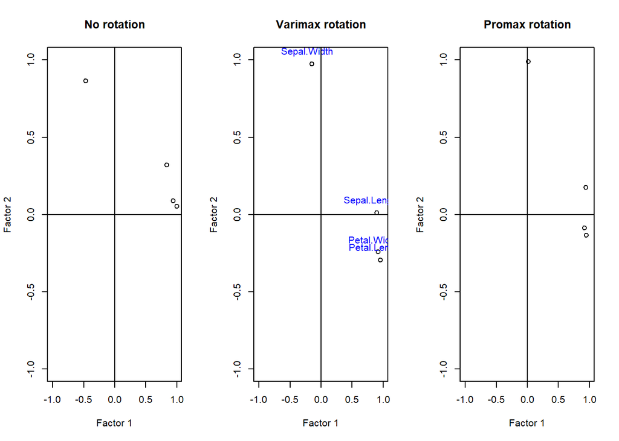

```r
fa.none <- psych::fa(df, nfactors = 2, rotate = "none")
fa.varimax <- psych::fa(df, nfactors = 2, rotate = "varimax")
fa.promax <- psych::fa(df, nfactors = 2, rotate = "promax")

par(mfrow = c(1,3))
plot(fa.none$loadings[,1],
     fa.none$loadings[,2],
     xlab = "Factor 1",
     ylab = "Factor 2",
     ylim = c(-1,1),
     xlim = c(-1,1),
     main = "No rotation")
abline(h = 0, v = 0)

plot(fa.varimax$loadings[,1],
     fa.varimax$loadings[,2],
     xlab = "Factor 1",
     ylab = "Factor 2",
     ylim = c(-1,1),
     xlim = c(-1,1),
     main = "Varimax rotation")

text(fa.varimax$loadings[,1]-0.08,
     fa.varimax$loadings[,2]+0.08,
     colnames(df),
     col="blue")
abline(h = 0, v = 0)

plot(fa.promax$loadings[,1],
     fa.promax$loadings[,2],
     xlab = "Factor 1",
     ylab = "Factor 2",
     ylim = c(-1,1),
     xlim = c(-1,1),
     main = "Promax rotation")
abline(h = 0, v = 0)
```

## Referência

- http://www.sthda.com/english/wiki/wiki.php?id_contents=7866
- https://www.statology.org/principal-components-analysis-in-r/
- https://users.dickinson.edu/~richesod/latex/latexcheatsheet.pdf
- http://ftp.demec.ufpr.br/disciplinas/TM788/Daniel%20Furtado%20Ferreira/Capitulo%203.pdf
- http://www.de.ufpb.br/~ulisses/disciplinas/notasdeaula-anamult.pdf
- https://willstenico.medium.com/puffindex-criando-um-ranking-de-a%C3%A7%C3%B5es-brasileiras-utilizando-pca-analise-de-componentes-2715f2ffc46a
- https://scentellegher.github.io/machine-learning/2020/01/27/pca-loadings-sklearn.html
- https://aaronschlegel.me/factor-analysis-principal-component-method-r.html
- https://rpubs.com/aaronsc32/factor-analysis-part-two
- https://www.geo.fu-berlin.de/en/v/soga/Geodata-analysis/factor-analysis/A-simple-example-of-FA/index.html